# 20172_M2.855_PEC2-Solucion

[figure not shown]

M2.855 · Modelos avanzados de minería de datos · PEC2

2017-1 · Máster universitario en Ciencia de datos (Data science)

Estudios de Informática, Multimedia y Telecomunicación

# PEC 2: Métodos no supervisados

A lo largo de esta práctica veremos como aplicar distintas técnicas no supervisadas así como algunas de sus aplicaciones reales:

1. **Clustering clásico**: k-means y la regla del codo.
2. **Más allá de k-means**: clustering jerárquico.
3. **Reducción de dimensionalidad**: PCA y t-SNE.
4. **Aplicaciones**:
   - Compresión de imágenes.
   - Segmentación de imágenes de satélite.

Para ello vamos a necesitar las siguientes librerías:

```python
import random

import numpy as np
import pandas as pd
from sklearn import cluster      # Algoritmos de clustering.
from sklearn import datasets     # Crear datasets.

# Visualizacion.
import matplotlib.pyplot as plt
import seaborn as sns

%matplotlib inline
```

## 1. Clustering clásico: k-means y la regla del codo (2 puntos)

Vamos a generar un dataset compuesto por $n$ nubes de puntos, donde $n$ será un número aleatorio entre 2 y 4, usando el módulo `datasets` de scikit-learn.

```
Hay 1500 puntos en 2 dimensiones (repartidos en 3 clusters)
```

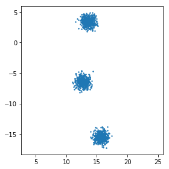

```python
N_SAMPLES = 1500
MIN_CLUSTERS = 2
MAX_CLUSTERS = 4
X, y = datasets.make_blobs(n_samples=N_SAMPLES, # Cuantos puntos
                           n_features=2,        # Cuantas dimensiones
                           centers=random.randint(MIN_CLUSTERS, MAX_CLUSTERS),
                           center_box=(-20, 20),
                           cluster_std=.6)
print('Hay {} puntos en {} dimensiones (repartidos en {} clusters)'.format(X.shape[0], X.shape[1], y.max() + 1))
fig, ax = plt.subplots(1, 1, figsize=(4, 4))
ax.scatter(X[:,0], X[:,1], s=2)
ax.axis('equal')
plt.tight_layout()
```

Una técnica para estimar $k$ es, como se explica en la teoría:

> Los criterios anteriores (minimización de distancias intra grupo o maximización de distancias inter grupo) pueden usarse para establecer un valor adecuado para el parámetro k. Valores k para los que ya no se consiguen mejoras significativas en la homogeneidad interna de los segmentos o la heterogeneidad entre segmentos distintos, deberían descartarse.

Lo que popularmente se conocer como *regla del codo*.

Primero es necesario calcular la suma de los errores cuadráticos ([*SSE*](https://bl.ocks.org/rpgove/0060ff3b656618e9136b)) que consiste en la suma de todos los errores (distancia de cada punto a su centroide asignado) al cuadrado.

$$SSE = \sum_{i=1}^{K} \sum_{x \in C_i} euclidean(x, c_i)^2$$

Donde $K$ es el número de clusters a buscar por *k-means*, $x \in C_i$ son los puntos que pertenecen a i-ésimo cluster, $c_i$ es el centroide del cluster $C_i$ (al pertenece el punto $x$), y $euclidean$ es la [distancia euclídea](https://en.wikipedia.org/wiki/Euclidean_distance).

Este procedimiento realizado para cada posible valor $k$, resulta en una función monótona decreciente, donde el eje $x$ representa los distintos valores de $k$, y el eje $y$ el $SSE$. Intuitivamente se podrá observar un significativo descenso del error, que indicará el valor idóneo de $k$.

**Se pide realizar la representación gráfica de la regla del codo junto a su interpretación, utilizando la librería `matplotlib` y la implementación en scikit-learn de [*k-means*](http://scikit-learn.org/stable/modules/generated/sklearn.cluster.KMeans.html).**

**Implementación:** cálculo y visualización de la regla del codo.

**Solución:**

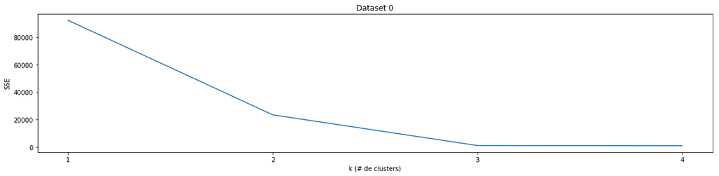

```python
#############################################
# SOLUCION                                  #
#############################################

from typing import List
from mypy_extensions import NoReturn

def plot_elbow_rule(datasets: List[np.array],
                    min_k: int = 1,
                    max_k: int = MAX_CLUSTERS) -> NoReturn:
    """Computes and shows SSE for each value of k in k-means.

    This is a generic solution that receives a list containing datasets,
    and shows a plot for each datset.

    Args:
        datasets: list
            A list of np.array with shape (points, dimensions).
        min_k: int
            The lowest value of k to try.
        max_k: int
            The highest value of k to try.
    """
    fig, ax = plt.subplots(1, len(datasets), figsize=(16, 4))
    for i, a in zip(range(len(datasets)), ax if type(ax) == np.ndarray else (ax,)):
        x = range(min_k, max_k + 1)
        y = []
        X = datasets[i]
        for nc in x:
            kmeans = cluster.KMeans(n_clusters=nc)
            dists = kmeans.fit_transform(X)
            y.append(np.sum(np.min(dists, axis=1) ** 2))
        a.plot(x, y)
        a.set_xlabel('k (# de clusters)')
        a.set_ylabel('SSE')
        a.set_title('Dataset {}'.format(i))
        a.set_xticks(range(min_k, max_k + 1))
    plt.tight_layout()

dists = plot_elbow_rule([X])
```

**Análisis:** ¿Qué se interpreta en la gráfica? ¿Cómo podría mejorarse la elección de $k$?.

**Solución:**  
**Cuidado, el número de clusters del dataset cambia con cada ejecución, por lo que la gráfica y el análisis pueden ser distintos para cada alumno.**  
Tal y como se esperaba, en la gráfica anterior puede observarse como a medida que aumenta el número de clusters se va reduciendo el error. A partir de $k=3$, el error se reduce significativamente y no se aprecia una notable reducción del error al aumentar el valor de $k$. Por lo que una decisión razonable es pensar que el número de clusters originales es de 3.  
Se puede afinar más con una métrica que no sólo utilice la distancia *intra-grupo* sino también la *inter-grupo*. Tal y como aparece en la teoría.

De forma **optativa** se plantea **realizar el apartado anterior con una implementación propia del algoritmo *k-means***.

**[OPCIONAL] Implementación:** algoritmo *k-means* desde cero.

En este caso, con 2 dimensiones, es muy sencillo inferir el número de clusters visualizando los datos. Pero este método es de gran utilidad cuando se cuenta con datos de alta dimensionalidad.

## 2. Más allá de k-means: clustering jerárquico (3 puntos)

Pero no todos los datasets son como los del ejercicio anterior. Para esta segunda parte vamos a emplear los siguientes conjuntos de datos:

```python
data_circles = ('circles', *datasets.make_circles(n_samples=N_SAMPLES, factor=.5, noise=.05))
data_moons = ('moons', *datasets.make_moons(n_samples=N_SAMPLES, noise=.05))
data_blobs = ('blobs', *datasets.make_blobs(n_samples=N_SAMPLES, random_state=8))
data_square = ('square', np.random.rand(N_SAMPLES, 2), np.array([0] * N_SAMPLES))

# Guardamos todos los datasets en una tupla.
datasets_tuple = (data_circles, data_moons, data_blobs, data_square)
```

Donde cada variable: *data_circles*, *data_moons*, *data_blobs* y *data_square* es una tupla con tres posiciones: el nombre del dataset y los dos valores devueltos por la función que genera el dataset:

```python
datasets.make_circles?
```

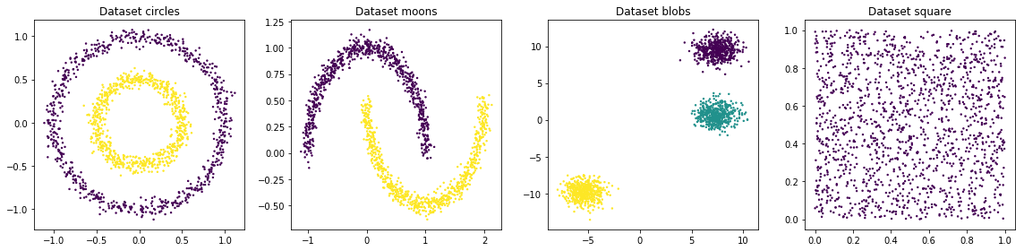

```python
fig, ax = plt.subplots(1, 4, figsize=(16, 4))
for data, axis in zip(datasets_tuple, ax.reshape(-1)):
    axis.scatter(data[1][:,0], data[1][:,1], c=data[2], s=2)
    axis.set_title('Dataset {}'.format(data[0]))
plt.tight_layout()
```

### 2 a. *k-means*

**Implementación:** aplica la regla del codo para decidir el valor de $k$ en cada uno de los datasets.

**Solución:**

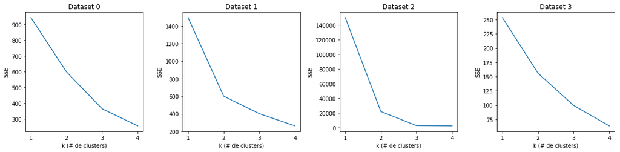

```python
#############################################
# SOLUCION                                  #
#############################################

plot_elbow_rule([data[1] for data in datasets_tuple])
```

**Implementación:** aplica *k-means* con el valor de $k$ elegido en cada dataset.  
Visualiza el resultado en un *scatter plot* representando cada cluster con un color distinto.

**Solución:**

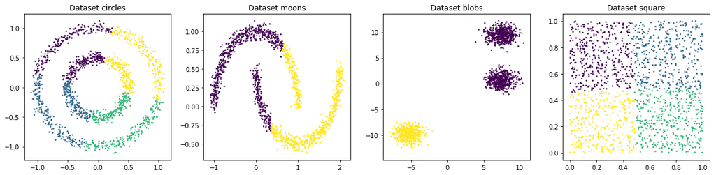

```python
#############################################
# SOLUCION                                  #
#############################################

fig, ax = plt.subplots(1, 4, figsize=(16, 4))
for data, k, axis in zip(datasets_tuple, (4, 4, 3, 4), ax.reshape(-1)):
    kmeans = cluster.KMeans(n_clusters=k)
    dists = kmeans.fit_transform(data[1])
    axis.scatter(data[1][:,0], data[1][:,1], c=np.argmax(dists, axis=1), s=2)
    axis.set_title('Dataset {}'.format(data[0]))
plt.tight_layout()
```

**Análisis:** ¿Qué ha sucedido? Explica los motivos por los que crees que se ha producido ese resultado.

**Solución:**  
Usando *k-means* con distancia euclídea asumimos que los clusters son n-esferas. En la práctica podemos verlo como una teselación de Voronoi, que es lo que se observa en los resultados anteriores.  
Es normal que no se produzcan los resultados esperados porque los clusters tienen distintas formas y no se ciñen a celdas de Voronoi.

### 2 b. Agrupamiento Jerárquico Aglomerativo

En este apartado se pide visualizar mediante un [dendrograma](https://en.wikipedia.org/wiki/Dendrogram) la construcción progresiva de los grupos mediante un algoritmo jerárquico aglomerativo (estrategia *bottom-up*). Con ello se pretende encontrar un método gráfico para determinar el número de clusters en cada escenario.

Como métrica se empleará la distancia euclídea, pero como [criterio de enlace o *linkage*](https://en.wikipedia.org/wiki/Hierarchical_clustering#Linkage_criteria) se pide probar distintos métodos para posteriormente comentar sus resultados.

**Implementación:** prueba distintos criterios de enlace con el método jerárquico aglomerativo para seleccionar el criterio de enlace que permita identificar los clusters subyacentes a través de su dendrograma.

**Solución:**

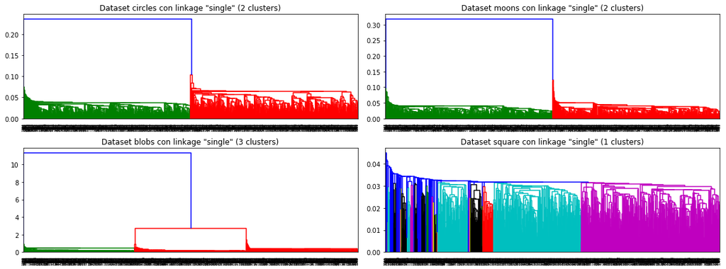

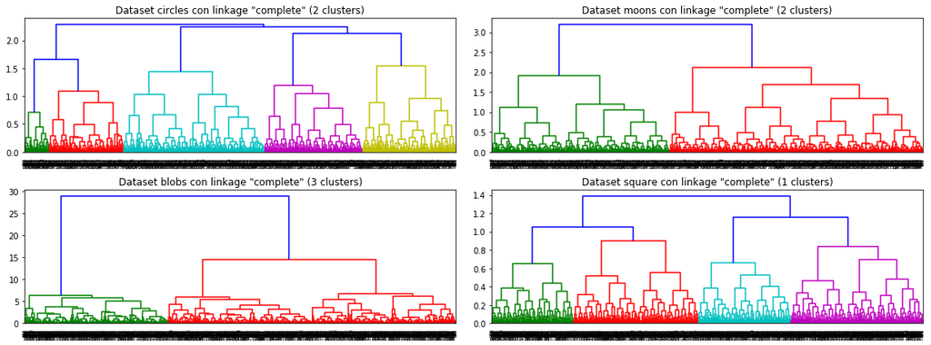

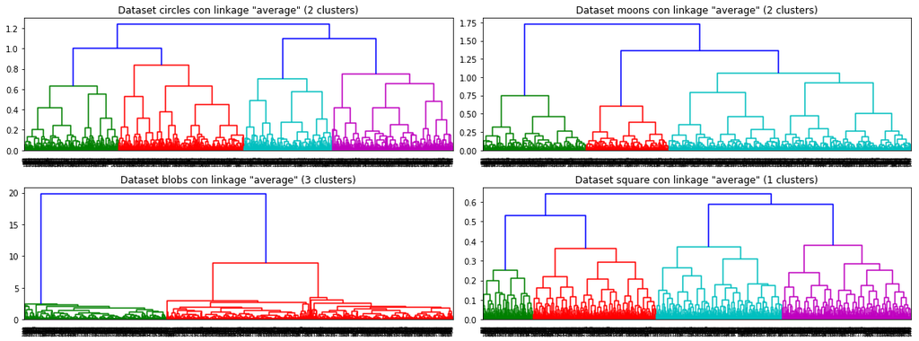

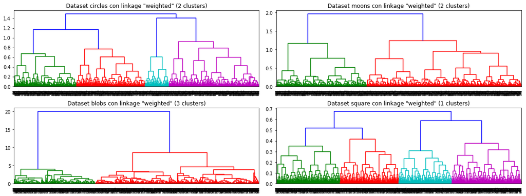

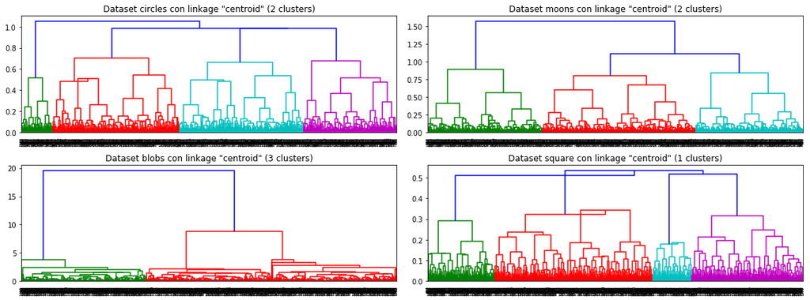

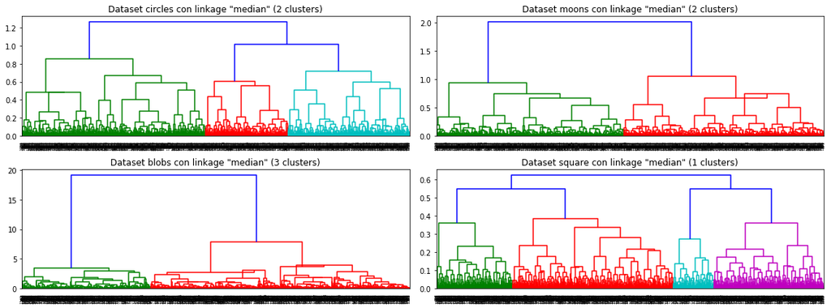

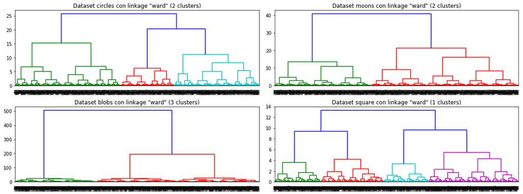

```python
#############################################
# SOLUCION                                  #
#############################################

from scipy.spatial.distance import pdist
from scipy.cluster.hierarchy import dendrogram, linkage

linkages = ['single', 'complete', 'average', 'weighted', 'centroid', 'median', 'ward']
for link in linkages:
    fig, ax = plt.subplots(2, 2, figsize=(16, 6))
    for data, axis in zip(datasets_tuple, ax.reshape(-1)):
        dendrogram(linkage(pdist(data[1]), link), ax=axis)
        axis.set_title('Dataset {} con linkage "{}" ({} clusters)'.format(data[0], link, np.max(data[2]) + 1))
    plt.tight_layout()
```

**Análisis:** ¿Qué criterio de enlace se comporta mejor para los distintos escenarios? ¿Por qué?

**Solución:**
El enlace simple es el que, para estos datasets, permite distinguir mejor los clusters esperados.
- Dataset circles: se observan claramente dos grupos bien diferenciados, uno para cada círculo.
- Dataset moons: igual que en el caso anterior.
- Dataset blobs: aquí se aprecia como dos clusters bien diferenciados están muy juntos (los grupos de la derecha) y más lejos el último cluster.
- Dataset square: no se observa un comportamiento tan diferenciado como en los casos anteriores, porque sólo existe un único grupo.
El enlace simple, definido como la mínima distancia entre elementos de cada cluster:
$$d(A, B)\min\{\,d(x,y):x\in A,\,y\in B\,\}$$
Donde $x$ e $y$ son elementos de distintos clusters ($A$ y $B$). La intuición detrás de este criterio de enlace es ir juntando los clusters a través de sus puntos más próximos. De esta forma, se van dibujando las formas de los clusters, permitiendo encontrar formas complejas bien separadas entre ellas.

**Implementación:** tras seleccionar el criterio de enlace y los umbrales (eje de ordenadas del dendrograma) en el paso anterior. Para cada dataset, se pide visualizar un *scatter plot* donde cada cluster quede representado un color distinto.

**Solución:**

```
Dataset circles, se esperan: 2 clusters, encontrados: 2
Dataset moons, se esperan: 2 clusters, encontrados: 2
Dataset blobs, se esperan: 3 clusters, encontrados: 3
Dataset square, se esperan: 1 clusters, encontrados: 1
```

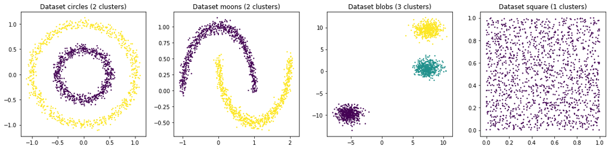

```python
#############################################
# SOLUCION                                  #
#############################################

from scipy.cluster.hierarchy import fcluster

fig, ax = plt.subplots(1, 4, figsize=(16, 4))
for data, thld, axis in zip(datasets_tuple, (.15, .2, 2, 1), ax.reshape(-1)):
    cluster_idx = fcluster(linkage(pdist(data[1]), 'single'), t=thld, criterion='distance')
    axis.scatter(data[1][:,0], data[1][:,1], c=cluster_idx, s=2)
    axis.set_title('Dataset {} ({} clusters)'.format(data[0], np.max(data[2]) + 1))
    print('Dataset {}, se esperan: {} clusters, encontrados: {}'.format(data[0], np.max(data[2]) + 1, max(cluster_idx)))
plt.tight_layout()
```

## 3. Reducción de dimensionalidad: PCA y t-SNE (3 puntos)

Al plantear un problema de clasificación con un dataset de más de tres atributos (dimensiones), no se puede realizar una visualización clásica del dataset para entender los datos. Por ello, uno de los usos de los métodos de reducción de dimensionalidad es transformar los datos de más de 4 dimensiones a 3 o menos para poder visualizarlos.

### 3 a. PCA

El [dataset Iris](https://es.wikipedia.org/wiki/Iris_flor_conjunto_de_datos) contiene 4 atributos sobre tres tipos de flores.

```python
iris = datasets.load_iris()
X = iris.data   # np.array con shape (150, 4)
y = iris.target # np.array con shape (150,)
```

Al exceder las 3 dimensiones necesitaremos más de una visualización para entender los datos.

Para solucionarlo, una alternativa es usar los [*pair plots*](http://seaborn.pydata.org/generated/seaborn.pairplot.html) que enfrentan pares de dimensiones para tratar de dar una visión global a partir de un [DataFrame](https://pandas.pydata.org/pandas-docs/stable/dsintro.html):

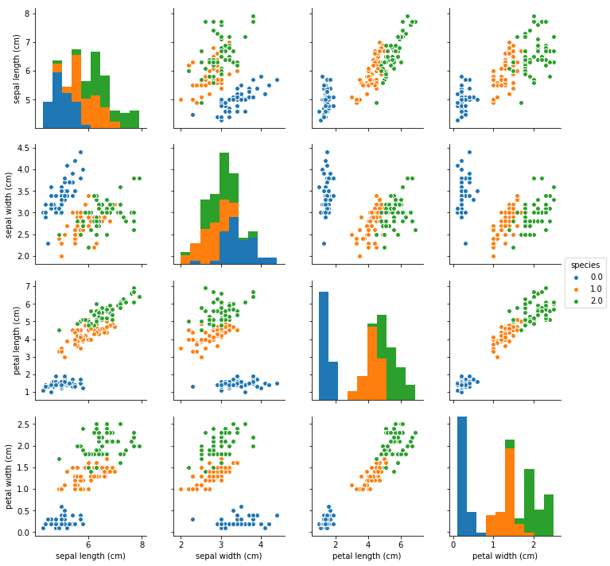

```python
# DataFrame
iris_df = pd.DataFrame(np.hstack([X, y.reshape(-1, 1)]), columns=iris.feature_names + ['species'])
sns.pairplot(iris_df, vars=iris.feature_names, hue="species")
```

Como alternativa a las múltiples gráficas que generan los gráficos pareados, se plantea utilizar una técnica de reducción de dimensionalidad para pasar de 4 dimensiones a 2. Nótese que gráficas como *longitud de pétalo* vs *anchura de pétalo* muestran cierta separabilidad (los 3 tipos de flores están aparentemente separados).

**Implementación:** realizar una reducción de dimensionalidad con PCA para pasar de 4 dimensiones a 2 y crear una visualización donde el color de los puntos dependa del tipo de flor a la que pertenece.

**Solución:**

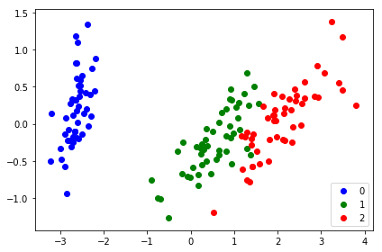

```python
#############################################
# SOLUCION                                  #
#############################################

from sklearn import decomposition

X_prime = decomposition.PCA(n_components=2).fit_transform(X)
for i, color in zip(range(3), ['b', 'g', 'r']):
    indexes = y == i
    plt.scatter(X_prime[indexes,0], X_prime[indexes,1], c=color, label=str(i))
plt.legend(loc='best')
plt.tight_layout()
```

**Análisis:** ¿El resultado de la reducción de dimensionalidad mantiene la separabilidad? ¿Era de esperar? ¿Por qué?

**Solución:**  
- El resultado es separable.  
- No, no es uno de los objetivos de PCA.  
- Porque PCA trata de maximizar la varianza tras la proyección para reducir la dimensionalidad, y en ningún momento tiene información de las etiquetas (no es supervisado, ¡por eso está en esta práctica!).

### 3 b. t-SNE (t-distributed Stochastic Neighbor Embedding)

El uso de técnicas de reducción de dimensionalidad es de gran utilidad cuando esta es muy alta. Por ejemplo, el [dataset Digits](http://scikit-learn.org/stable/auto_examples/classification/plot_digits_classification.html) contiene 1797 imágenes de números del 0 al 9, de 8 por 8 píxeles. Si se toma cada pixel como una dimensión, eso se traduce en que cada muestra tiene ¡64 dimensiones!

```python
digits = datasets.load_digits()
X = digits.data   # np.array con shape (1797, 64)
y = digits.target # np.array con shape (1797,)
```

Ejemplo de los 24 primeros dígitos de 8 por 8 píxeles junto a su etiqueta presentes en el dataset:

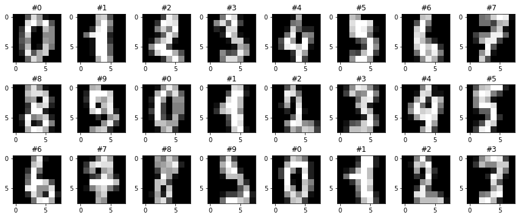

```python
fig, ax = plt.subplots(3, 8, figsize=(12, 5))
for i, axis in zip(range(24), ax.reshape(-1)):
    axis.imshow(X[i,:].reshape(8, 8), cmap='gray')
    axis.set_title('#{}'.format(y[i]))
plt.tight_layout()
```

Con un número tan elevado de dimensiones pierde sentido visualizar el dataset con un *pair plot* y aparecen otros peligos como la [maldición de la dimensionalidad](https://es.wikipedia.org/wiki/Maldici%C3%B3n_de_la_dimensi%C3%B3n). Para reducir su dimensión y así entender la estructura de los datos en alta dimensionalidad existen distintas alternativas con resultados muy distintos.

**Implementación:** realizar una reducción de dimensionalidad con PCA para pasar de 64 dimensiones a 2 y crear una visualización donde el color de los puntos dependa del dígito que pertenece.

**Solución:**

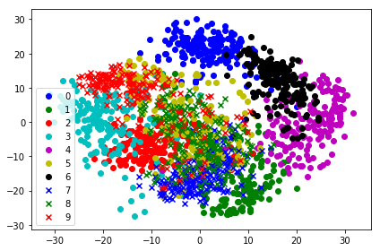

```python
#############################################
# SOLUCION                                  #
#############################################

X_prime = decomposition.PCA(n_components=2).fit_transform(X)
for i, color, marker in zip(range(10), ['b', 'g', 'r', 'c', 'm', 'y', 'k'] * 2, ['o'] * 7 + ['x'] * 7):
    indexes = y == i
    plt.scatter(X_prime[indexes,0], X_prime[indexes,1], c=color, marker=marker, label=str(i))
plt.legend(loc='best')
plt.tight_layout()
```

**Análisis:** ¿El resultado de la reducción de dimensionalidad mantiene la separabilidad? ¿Era de esperar? ¿Por qué?

**Solución:**  
- Esta vez el resultado no es separable.  
- No, no es uno de los objetivos de PCA.  
- Porque PCA trata de maximizar la varianza tras la proyección para reducir la dimensionalidad, no tratar de mantener su estructura.

El algoritmo [t-SNE](https://en.wikipedia.org/wiki/T-distributed_stochastic_neighbor_embedding) ideado por [van der Maaten y Hinton](https://lvdmaaten.github.io/tsne/) difiere de PCA en que no trata de maximizar la varianza explicada. Intuitivamente, t-SNE trata de que la vecindad de un punto en baja dimensionalidad sea la misma que la original. Partiendo de una localización aleatoria de cada punto, corrige su posición de forma iterativa tratando de minimizar la distancia a sus vecinos originales hasta converger.

Para ello, t-SNE dispone de diversos [parámetros](https://distill.pub/2016/misread-tsne/) que pueden modificar drásticamente el resultado. Por lo que se recomienda conocer su funcionamiento antes de aplicar la técnica.

**Implementación:** realizar una reducción de dimensionalidad con t-SNE para pasar de 64 dimensiones a 2 y crear una visualización donde el color de los puntos dependa del dígito que pertenece.

**Solución:**

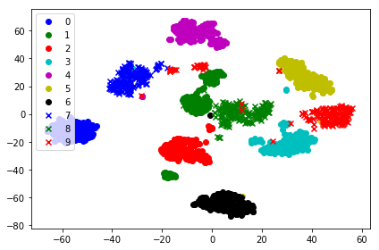

```python
#############################################
# SOLUCION                                  #
#############################################

from sklearn import manifold

X_prime = manifold.TSNE(n_components=2).fit_transform(X)
for i, color, marker in zip(range(10), ['b', 'g', 'r', 'c', 'm', 'y', 'k'] * 2, ['o'] * 7 + ['x'] * 7):
    indexes = y == i
    plt.scatter(X_prime[indexes,0], X_prime[indexes,1], c=color, marker=marker, label=str(i))
plt.legend(loc='best')
plt.tight_layout()
```

**Análisis:** ¿El resultado de la reducción de dimensionalidad mantiene la separabilidad? ¿Era de esperar? ¿Por qué?

**Solución:**  
- Ahora sí que el resultado aparenta ser separable.  
- Lo más probable es que sí, puesto que en alta dimensionalidad lo era.  
- Porque t-SNE trata de mantener en baja dimensionalidad los vecinos que un punto tiene en alta dimensionalidad, intentando mantener así parte de su estructura.

## 4. Aplicaciones

### 4 a. Compresión de imágenes (1 punto)

Las imágenes en color se componen de píxeles que tienen tres componentes (roja, azul y verde), destinando 1 *byte* a cada canal. Pudiendo representar $2^8 = 256$ rojos, verdes y azules. Con un total de $2^{8^{3}} = 2^{24} = 16777216$ colores representables en cada píxel.

Entre mayor sea el número de colores representables, más memoria será necesaria para almacenar la imagen. Por tanto, una estrategia para comprimir una imagen puede ser disminuir los colores representables en cada píxel, necesitando menos *bits* para guardar el valor de un píxel. Este método no es reversible, es decir, no se puede volver a recuperar la imagen original a partir de la comprimida. Por tanto, este tipo de compresiónse denomina [comprensión con pérdidas](https://es.wikipedia.org/wiki/Algoritmo_de_compresi%C3%B3n_con_p%C3%A9rdida).

Pero ¿cómo seleccionamos los "píxeles parecidos" en la imagen original y determinamos su color en la imagen comprimida?. Una opción es utilizar *k-means* donde **$k$ será el número de colores representables**, los puntos que pertenecen a cada cluster equivaldrían a los "píxeles parecidos" y las coordenadas de los **centroides actuarán como los colores finales** a los que se aproximarán los "píxeles parecidos".

Como resultado del clustering, se obtiene una paleta de colores reducida (coordenadas de los centroides) donde cada píxel de la imagen hará referencia a uno de estos colores (cluster al que pertenece). El uso de paletas de colores o [colores indexados](https://en.wikipedia.org/wiki/Indexed_color) es un recurso empleado por distintos formatos de imagen como *PNG*, *GIF* o *TIFF*.

```
Imagen con 33750 pixeles (101250 bytes)
```

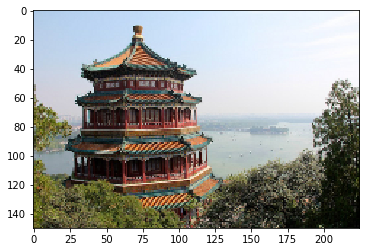

```python
from skimage import transform

photo = transform.resize(datasets.load_sample_image("china.jpg"), (150, 225), mode='edge')
plt.imshow(photo)
X = photo.reshape(-1, 3) # np.array con shape (33750, 3)
print('Imagen con {} pixeles ({} bytes)'.format(X.shape[0], X.shape[0] * 3))
```

Para facilitar la tarea, la imagen anterior está guardada en un *array* con tantas filas como píxeles y columnas como canales (rojo, verde y azul). De forma que cada "muestra" equivale al valor de un píxel.

Se puede volver a recomponer la imagen original con:

```
plt.imshow(X.reshape(photo.shape))
```

Podemos ver cada píxel como un punto en un sistema de coordenadas de 3 dimensiones donde una es su cantidad de rojo, otra su cantidad de verde y por último su cantidad de azul. Por lo que podemos realizar una visualización en 3 dimensiones de los píxeles sobre la que se probará el algoritmo de clustering:

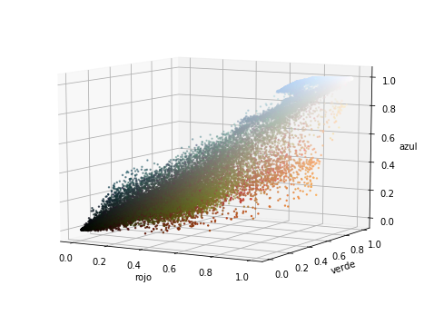

```python
from mypy_extensions import NoReturn
from mpl_toolkits.mplot3d import Axes3D

def plot_pixels_3d(data: "np.array[float]", elev: int = None, azim: int = None) -> NoReturn:
    """Visualiza pixeles en un scatter plot 3d (una por canal) con su color correspondiente.

    Args:
        data: np.array (puntos, 3)
        elev: int
            angulo de eleveacion en el plano z.
        azim: int
            angulo acimut en el plano x, y.
    """
    assert data.shape[1] == 3, 'Se esperaba un array bidimensional con 3 columnas: (rojo, verde y azul)'
    ax = plt.figure(figsize=(8, 6)).add_subplot(111, projection='3d')
    ax.scatter(data[:,0], data[:,1], data[:,2], s=2, c=data)
    ax.set_xlabel('rojo')
    ax.set_ylabel('verde')
    ax.set_zlabel('azul')
    ax.view_init(elev, azim)
    plt.show()

plot_pixels_3d(X, 10)
```

En la visualización anterior se ha representado cada píxel con su color, donde sus coordenadas en los 3 colores oscilan entre 0 (carece de esa componente) y 1. Podemos comprobar como los píxeles en coordenadas (1, 1, 1) (arriba a la derecha) son píxeles blancos y los situados en (0, 0, 0) son píxeles negros. También se observan 3 nubes de píxeles: una azul, donde están los píxeles del cielo y agua, otra verde que se corresponde con los píxeles de la vegetación y una rojiza para la pagoda.

**Implementación:** representar la imagen con 256, 128, 64, 32, 16, 8, 4 y 2 colores e indicar los bytes que ocuparía cada una de las opciones.

**Solución:**

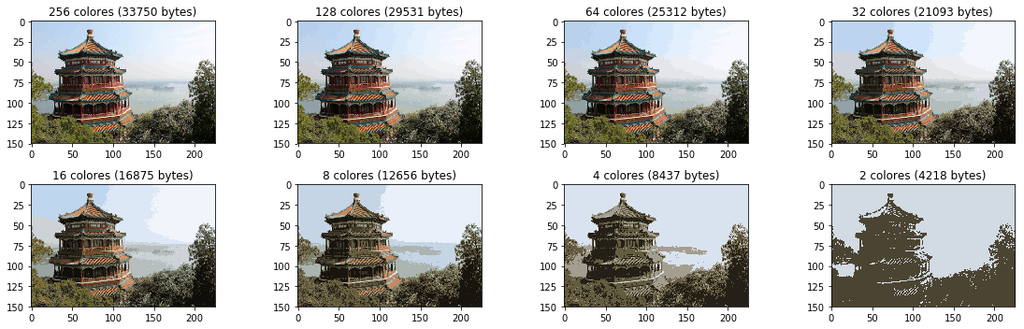

```python
#############################################
# SOLUCION                                  #
#############################################

fig, ax = plt.subplots(2, 4, figsize=(16, 5))
for i, axis in zip(range(1, 9), ax.reshape(-1).tolist()[::-1]):
    kmeans = cluster.KMeans(n_clusters=2 ** i, n_jobs=-1)
    labels = kmeans.fit_predict(X)
    colors = kmeans.cluster_centers_
    axis.imshow(colors[labels].reshape(photo.shape))
    axis.set_title('{} colores ({} bytes)'.format(2 ** i, int(X.shape[0] * i / 8)))
plt.tight_layout()
```

**Análisis:** Describe el comportamiento de *k-means* sobre las imágenes. ¿Otro algoritmo produciría un resultado distinto? ¿qué diferencias y por qué?

**Solución:**  
- *k-means* hace un buen trabajo aproximando colores, las últimas imágenes nos muestran cuales son los colores dominantes.  
- Sí, uno jerárquico o por densidad produciría resultados distintos.  
- Una de las principales diferencias sería como tratan los degradados (por ejemplo el cielo). *K-means* divide regiones con degradado en secciones, mientras que un clustering jerárquico o por densidad (dependiendo de los parámetros) probablemente trataría el cielo como una región homogénea.

**[OPCIONAL] Implementación:** realiza la compresión de imágenes con otro algoritmo de clustering.

### 4 b. Segmentación de imágenes de satélite (1 punto)

Hoy en día los mapas de carreteras, geológicos, agrícolas... se confeccionan con imágenes satélites. Para ello es necesario interpretar esas imágenes buscando en ellas los elementos de interés. Dado el volumen actual de imágenes que generan los satélites, hacer la segmentación de forma manual no es una opción y por ello hay tantos esfuerzos en su automatización.

Asumiendo que el espacio de píxeles tiene cierta estructura y que los distintos elementos a buscar son grupos en ella. Es razonable pensar que una estrategia de clustering (entre muchas otras) puede hallar estos grupos en dicha estructura, permitiendo automatizar la segmentación de imágenes.

Partimos de una imagen con diversos tipos de vegetación y caminos:

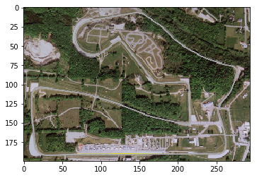

```python
from skimage import io, transform

photo = transform.resize(
    io.imread('http://www.trackcreation.net/devdiary/images/road_america_base.jpg'),
    (200, 294), mode='edge')
plt.imshow(photo)
X = photo.reshape(-1, 3)
```

Al igual que en el apartado anterior, se ha dado un formato de *array* a la imagen con tantas filas como píxeles y 3 columnas (una por canal).

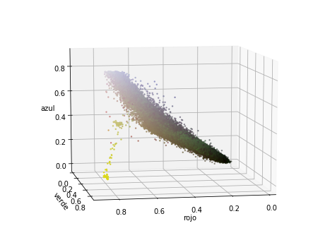

```python
plot_pixels_3d(X, 10, 80)
```

Visualizando en 3 dimensiones los píxeles de la imagen vemos que en este caso no están tan diferenciados los grupos. Pero sí que los píxeles más claros pertenecen a la zona de caminos y los más oscuros al área de vegetación.

**Implementación:** aplica una técnica de clustering para separar los caminos de la vegetación y visualiza tanto la imagen original como la resultante tras aplicar la segmentación para comparar el resultado.

**Solución:**

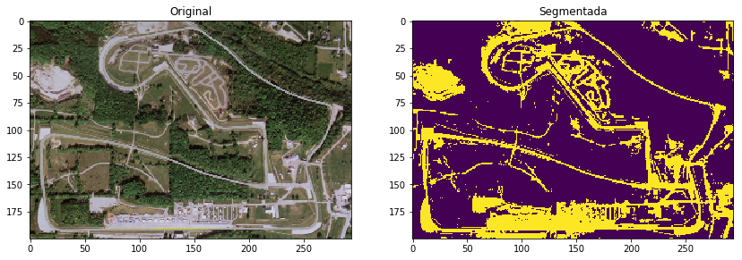

```python
#############################################
# SOLUCION                                  #
#############################################

fig, ax = plt.subplots(1, 2, figsize=(12, 4))
kmeans = cluster.KMeans(n_clusters=2, n_jobs=-1)
labels = kmeans.fit_predict(X)
ax[0].imshow(photo)
ax[0].set_title('Original')
ax[1].imshow(labels.reshape(photo.shape[:2]))
ax[1].set_title('Segmentada')
plt.tight_layout()
```

**Implementación y análisis:** vuelve a aplicarlo buscando 3 clusters. ¿Qué region representa cada uno de ellos?

**Solución:**  
Un cluster para las carreteras, otro para la zona de cesped y por último otro para la zona de árboles.

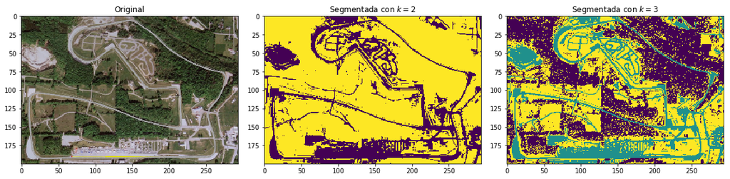

```python
#############################################
# SOLUCION                                  #
#############################################

fig, ax = plt.subplots(1, 3, figsize=(16, 4))
kmeans2 = cluster.KMeans(n_clusters=2, n_jobs=-1)
labels2 = kmeans2.fit_predict(X)
kmeans3 = cluster.KMeans(n_clusters=3, n_jobs=-1)
labels3 = kmeans3.fit_predict(X)
ax[0].imshow(photo)
ax[0].set_title('Original')
ax[1].imshow(labels2.reshape(photo.shape[:2]))
ax[1].set_title('Segmentada con $k=2$')
ax[2].imshow(labels3.reshape(photo.shape[:2]))
ax[2].set_title('Segmentada con $k=3$')
plt.tight_layout()
```